Liam Healy

Site link: whealy4.github.io

# Terrorism: What Factors & Events Can Lead to an Attack?

# Milestone 1: Groups, Data, Website, and Extraction, Transform, and Load (ETL)

Terrorism causes fear and terror, as it is aptly named, across the world. People commit acts of terror for political, religious, and personal reasons along with many more. In addition, these are committed in multiple ways — e.g. bombing, kidnapping, assault, etc. — with a variety of weapons such as IEDs, assault rifles, poison, etc. Terrorism has often been used as a weapon of fear, not by the terrorists themselves, but by the state that has just been attacked to further their goals by convincing their populace their goals must be achieved to prevent more terror. Through the Global Terrorism Database (GTD), I hope to robustly analyze data of acts of terror from 1970 to 2019.

How does one classify an attack as that of a terrorist? In what countries are certain acts of terror most committed? Can we predict what country or region will be attacked given their method and target of terror?

Fortunately, the GTD appears to have the answer to all of the above and more, but the analysis can be potentially taken further with the inclusion of the Global Database of Events, Language, and Tone (GDELT). Regarding the terrorists themselves, people do not simply one day wake up and decide to commit an act of terror. There are many outside factors that can affect such a drastic decision. Countries getting sanctioned by other countries may either lead to or be indicative of general instability within the region. What are the impacts of a country halting negotiations with another, expelling immigrants, mobilizing their military? The GDELT contains events describing all of the above and 200 more.

With data from the GTD and GDELT databases, can multiple events and factors come together to predict a terrorist attack occurring or the frequency at which they may occur over a given time?

## Reading in Data

```python
!pip install openpyxl
```

```python
%matplotlib inline
import pandas as pd
from pandas import ExcelWriter
from pandas import ExcelFile
import numpy as np
import matplotlib
import matplotlib.pyplot as plt
import matplotlib.dates as dates
from matplotlib.pyplot import cm
from matplotlib.patches import Patch
from scipy import stats
```

Read in GDELT data extracted using Google BigQuery

```python
gdelt_df = pd.read_csv('./data/gdelt_data.csv')
gdelt_df = gdelt_df.sort_values(by='SQLDATE')
gdelt_df.head()
```

|  | SQLDATE | Actor1Code | Actor1Name | Actor1CountryCode | Actor1KnownGroupCode | Actor1Religion1Code | Actor2Code | Actor2Name | Actor2CountryCode | Actor2KnownGroupCode | Actor2Religion1Code | EventCode | EventBaseCode | EventRootCode | GoldsteinScale | Actor1Geo_Lat | Actor1Geo_Long | Actor2Geo_Lat | Actor2Geo_Long |
| --- | --- | --- | --- | --- | --- | --- | --- | --- | --- | --- | --- | --- | --- | --- | --- | --- | --- | --- | --- |
| 8204716 | 19200101 | USA | NEW YORK | USA | NaN | NaN | NaN | NaN | NaN | NaN | NaN | 172 | 172 | 17 | -5.0 | 36.1700 | -119.7460 | NaN | NaN |
| 8204721 | 19200101 | JUD | ADVOCATE | NaN | NaN | NaN | NaN | NaN | NaN | NaN | NaN | 172 | 172 | 17 | -5.0 | 38.8951 | -77.0364 | NaN | NaN |
| 8204722 | 19200101 | LAB | UNIONS | NaN | NaN | NaN | NaN | NaN | NaN | NaN | NaN | 172 | 172 | 17 | -5.0 | 38.8951 | -77.0364 | NaN | NaN |
| 8204723 | 19200101 | OPP | DEMONSTRATOR | NaN | NaN | NaN | USA | WASHINGTON | USA | NaN | NaN | 172 | 172 | 17 | -5.0 | 38.8951 | -77.0364 | 38.8951 | -77.0364 |
| 8204724 | 19200101 | GOVHLH | HEALTH OFFICIAL | NaN | NaN | NaN | GOV | PRESIDENT | NaN | NaN | NaN | 172 | 172 | 17 | -5.0 | 38.8951 | -77.0364 | 38.8951 | -77.0364 |

Separate query made for peacekeepers because left out of original query

```python
pce_df = pd.read_csv('./data/peacekeepers_and_more.csv')
gdelt_df = pd.concat([gdelt_df, pce_df])
```

```python
gdelt_df = gdelt_df[(gdelt_df['SQLDATE'].astype(int) >= 19700101) & (gdelt_df['SQLDATE'].astype(int) <= 20191231)]
gdelt_df = gdelt_df.reset_index()
gdelt_df = gdelt_df.drop(['index'], axis=1)
gdelt_df.head()
```

|  | SQLDATE | Actor1Code | Actor1Name | Actor1CountryCode | Actor1KnownGroupCode | Actor1Religion1Code | Actor2Code | Actor2Name | Actor2CountryCode | Actor2KnownGroupCode | Actor2Religion1Code | EventCode | EventBaseCode | EventRootCode | GoldsteinScale | Actor1Geo_Lat | Actor1Geo_Long | Actor2Geo_Lat | Actor2Geo_Long | AvgTone |
| --- | --- | --- | --- | --- | --- | --- | --- | --- | --- | --- | --- | --- | --- | --- | --- | --- | --- | --- | --- | --- |
| 0 | 19790101 | VATGOV | VATICAN | VAT | NaN | NaN | CHL | CHILE | CHL | NaN | NaN | 172 | 172 | 17 | -5.0 | -34.00 | -64.000 | -34.0000 | -64.000 | NaN |
| 1 | 19790101 | CRM | KIDNAPPER | NaN | NaN | NaN | CAN | CANADA | CAN | NaN | NaN | 81 | 81 | 8 | 5.0 | 60.00 | -95.000 | 60.0000 | -95.000 | NaN |
| 2 | 19790101 | KHMREB | CAMBODIAN | KHM | NaN | NaN | KHM | CAMBODIAN | KHM | NaN | NaN | 172 | 172 | 17 | -5.0 | 11.55 | 104.917 | 11.5500 | 104.917 | NaN |
| 3 | 19790101 | ARG | ARGENTINA | ARG | NaN | NaN | CHL | CHILE | CHL | NaN | NaN | 172 | 172 | 17 | -5.0 | -34.00 | -64.000 | -30.0000 | -71.000 | NaN |
| 4 | 19790101 | EGY | EGYPTIAN | EGY | NaN | NaN | PSE | PALESTINIAN | PSE | NaN | NaN | 1044 | 104 | 10 | -5.0 | 27.00 | 30.000 | 31.6667 | 35.250 | NaN |

Create Datetime Objects from SQLDATE for potential comparisons with GTD

```python
gdelt_df['date'] = pd.to_datetime(gdelt_df['SQLDATE'], format='%Y%m%d')
gdelt_df.head()
```

|  | SQLDATE | Actor1Code | Actor1Name | Actor1CountryCode | Actor1KnownGroupCode | Actor1Religion1Code | Actor2Code | Actor2Name | Actor2CountryCode | Actor2KnownGroupCode | ... | EventCode | EventBaseCode | EventRootCode | GoldsteinScale | Actor1Geo_Lat | Actor1Geo_Long | Actor2Geo_Lat | Actor2Geo_Long | AvgTone | date |
| --- | --- | --- | --- | --- | --- | --- | --- | --- | --- | --- | --- | --- | --- | --- | --- | --- | --- | --- | --- | --- | --- |
| 0 | 19790101 | VATGOV | VATICAN | VAT | NaN | NaN | CHL | CHILE | CHL | NaN | ... | 172 | 172 | 17 | -5.0 | -34.00 | -64.000 | -34.0000 | -64.000 | NaN | 1979-01-01 |
| 1 | 19790101 | CRM | KIDNAPPER | NaN | NaN | NaN | CAN | CANADA | CAN | NaN | ... | 81 | 81 | 8 | 5.0 | 60.00 | -95.000 | 60.0000 | -95.000 | NaN | 1979-01-01 |
| 2 | 19790101 | KHMREB | CAMBODIAN | KHM | NaN | NaN | KHM | CAMBODIAN | KHM | NaN | ... | 172 | 172 | 17 | -5.0 | 11.55 | 104.917 | 11.5500 | 104.917 | NaN | 1979-01-01 |
| 3 | 19790101 | ARG | ARGENTINA | ARG | NaN | NaN | CHL | CHILE | CHL | NaN | ... | 172 | 172 | 17 | -5.0 | -34.00 | -64.000 | -30.0000 | -71.000 | NaN | 1979-01-01 |
| 4 | 19790101 | EGY | EGYPTIAN | EGY | NaN | NaN | PSE | PALESTINIAN | PSE | NaN | ... | 1044 | 104 | 10 | -5.0 | 27.00 | 30.000 | 31.6667 | 35.250 | NaN | 1979-01-01 |

5 rows × 21 columns

Read in the GTD data

```python
df = pd.read_excel('./data/globalterrorismdb_0221dist.xlsx')
df_1993 = pd.read_excel('./data/gtd1993_0221dist.xlsx')
```

The 1993 data was left out, so it must be added to the data set and placed into the right location, between 1992 and 1994.

```python
gtd_df = pd.concat([df_1993, df])
gtd_df = gtd_df.sort_values(by=['eventid'])
gtd_df = gtd_df.reset_index()
gtd_df.drop(['index'],axis=1)
gtd_df.head()
```

|  | index | eventid | iyear | imonth | iday | approxdate | extended | resolution | country | country_txt | ... | addnotes | scite1 | scite2 | scite3 | dbsource | INT_LOG | INT_IDEO | INT_MISC | INT_ANY | related |
| --- | --- | --- | --- | --- | --- | --- | --- | --- | --- | --- | --- | --- | --- | --- | --- | --- | --- | --- | --- | --- | --- |
| 0 | 0 | 197000000001 | 1970 | 7 | 2 | NaN | 0 | NaT | 58 | Dominican Republic | ... | NaN | NaN | NaN | NaN | PGIS | 0 | 0 | 0 | 0 | NaN |
| 1 | 1 | 197000000002 | 1970 | 0 | 0 | NaN | 0 | NaT | 130 | Mexico | ... | NaN | NaN | NaN | NaN | PGIS | 0 | 1 | 1 | 1 | NaN |
| 2 | 2 | 197001000001 | 1970 | 1 | 0 | NaN | 0 | NaT | 160 | Philippines | ... | NaN | NaN | NaN | NaN | PGIS | -9 | -9 | 1 | 1 | NaN |
| 3 | 3 | 197001000002 | 1970 | 1 | 0 | NaN | 0 | NaT | 78 | Greece | ... | NaN | NaN | NaN | NaN | PGIS | -9 | -9 | 1 | 1 | NaN |
| 4 | 4 | 197001000003 | 1970 | 1 | 0 | NaN | 0 | NaT | 101 | Japan | ... | NaN | NaN | NaN | NaN | PGIS | -9 | -9 | 1 | 1 | NaN |

5 rows × 136 columns

Create datetime objects and add to new column 'date' to enable easy date access. However, it has an incredibly slow runtime relative to the rest of the analysis.

```python
gtd_df['date'] = 0

# There's gotta be a faster way to do this
for i, (y, m, d) in enumerate(zip(gtd_df['iyear'], gtd_df['imonth'], gtd_df['iday'])):
    if m == 0:
        gtd_df.loc[i,'date'] = pd.to_datetime(y, format='%Y')
    else:
        if d == 0:
            gtd_df.loc[i, 'date'] = pd.to_datetime(str(y)+str(m), format='%Y%m')
        else:
            gtd_df.loc[i, 'date'] = pd.to_datetime(str(y)+str(m)+str(d), format='%Y%m%d',errors='coerce')
```

```python
gtd_df['date'] = pd.DatetimeIndex(gtd_df['date']).normalize()
```

Drop columns that do not appear to be of any use. Rename columns with multiple dropped types. Replace data indicating nothing with NaNs.

```python
drop_cols = ['extended','resolution','vicinity','gname2','gsubname2','gname3','gsubname3',
             'guncertain2','guncertain3','claimmode','claimmode_txt','claim2','claimmode2','claimmode2_txt',
             'claim3','claimmode3','claimmode3_txt','compclaim','nhours','ndays','divert','ransomnote','addnotes',
             'scite1','scite2','scite3','dbsource','imonth','iday','approxdate']
# Potential drops: specificity, multiple, related
gtd_df.drop(columns=drop_cols)
gtd_df = gtd_df.rename(columns={'attacktype1':'attacktype','attacktype1_txt':'attacktype_txt','targtype1':'targtype',
                                'targtype1_txt':'targtype_txt', 'natlty1':'natlty','natlty1_txt':'natlty_txt'})
gtd_df = gtd_df.replace(-99, np.nan)
gtd_df = gtd_df.replace(-9, np.nan)
```

The countries in the GTD and GDELT databases do not align correctly in many cases, so we must link them via corresponding ISO 3166-1 Alpha-3 codes (i.e. their 3-letter country codes)

```python
# Convert names to match names in GDT
countries = pd.read_csv('./data/countries.csv')
countries = countries.loc[:, ['name', 'alpha-3']]
countries['name'] = countries['name'].str.lower()
countries.at[235, 'name'] = 'united states'
countries['name'].iloc[230:]
country_names = countries.name.unique()
countries = countries.set_index('name')
countries.head()
```

| name | alpha-3 |
| --- | --- |
| afghanistan | AFG |
| åland islands | ALA |
| albania | ALB |
| algeria | DZA |
| american samoa | ASM |

If country_txt in GTD matches that of countries, add the corresponding 'alpha-3' country code from countries. Repeat with GDELT

```python
gtd_df['country_txt_lower'] = gtd_df['country_txt'].str.lower()

def gtd_country_match(row):
    if row['country_txt_lower'] in country_names:
        return countries.loc[row['country_txt_lower']]
        print(countries.loc[row['country_txt_lower']])

gtd_df['country_code'] = gtd_df.apply (lambda row: gtd_country_match(row), axis=1)
gtd_df.head()
```

|  | index | eventid | iyear | imonth | iday | approxdate | extended | resolution | country | country_txt | ... | scite3 | dbsource | INT_LOG | INT_IDEO | INT_MISC | INT_ANY | related | date | country_txt_lower | country_code |
| --- | --- | --- | --- | --- | --- | --- | --- | --- | --- | --- | --- | --- | --- | --- | --- | --- | --- | --- | --- | --- | --- |
| 0 | 0 | 197000000001 | 1970 | 7 | 2 | NaN | 0 | NaT | 58 | Dominican Republic | ... | NaN | PGIS | 0.0 | 0.0 | 0.0 | 0.0 | NaN | 1970-07-02 | dominican republic | DOM |
| 1 | 1 | 197000000002 | 1970 | 0 | 0 | NaN | 0 | NaT | 130 | Mexico | ... | NaN | PGIS | 0.0 | 1.0 | 1.0 | 1.0 | NaN | 1970-01-01 | mexico | MEX |
| 2 | 2 | 197001000001 | 1970 | 1 | 0 | NaN | 0 | NaT | 160 | Philippines | ... | NaN | PGIS | NaN | NaN | 1.0 | 1.0 | NaN | 1970-01-01 | philippines | PHL |
| 3 | 3 | 197001000002 | 1970 | 1 | 0 | NaN | 0 | NaT | 78 | Greece | ... | NaN | PGIS | NaN | NaN | 1.0 | 1.0 | NaN | 1970-01-01 | greece | GRC |
| 4 | 4 | 197001000003 | 1970 | 1 | 0 | NaN | 0 | NaT | 101 | Japan | ... | NaN | PGIS | NaN | NaN | 1.0 | 1.0 | NaN | 1970-01-01 | japan | JPN |

5 rows × 139 columns

Extract regions from GTD corresponding to the country code to link with GDELT

```python
reg_merge_df = gtd_df[['country_code', 'region_txt']].drop_duplicates(subset='country_code').reset_index().drop(columns=['index'])
country_codes = reg_merge_df['country_code'].unique()
reg_merge_df = reg_merge_df.set_index('country_code')
reg_merge_df.head()
```

| country_code | region_txt |
| --- | --- |
| DOM | Central America & Caribbean |
| MEX | North America |
| PHL | Southeast Asia |
| GRC | Western Europe |
| JPN | East Asia |

Apply region mapping to both Actor1 and Actor2 in the GDELT because Actor1 is the country performing the event, and Actor2 is the country impacted by the event, so they have individual country codes.

```python
def gdelt_region_match1(row):
    if row['Actor1Code'] in country_codes:
        return reg_merge_df.loc[row['Actor1Code']][0]

def gdelt_region_match2(row):
    if row['Actor2Code'] in country_codes:
        return reg_merge_df.loc[row['Actor2Code']][0]

gdelt_df['Actor1Region'] = gdelt_df.apply (lambda row: gdelt_region_match1(row), axis=1)
gdelt_df['Actor2Region'] = gdelt_df.apply (lambda row: gdelt_region_match2(row), axis=1)
```

```python
%store gdelt_df
```

```
Stored 'gdelt_df' (DataFrame)
```

```python
# %store -r gdelt_df
# gdelt_df.head()
```

Store and access variables that take a long time to process

```python
%store gtd_df
```

```
Stored 'gtd_df' (DataFrame)
```

```python
# %store -r gtd_df
# gtd_df.head()
```

# Milestone 2: Additional Extraction, Transform, and Load (ETL) + Exploratory Data Analysis (EDA)

A basic analysis of the regions with the most acts of terror show the Middle East & Northern Africa along with South Asia in a clear lead, most likely due to greater political instability within the regions.

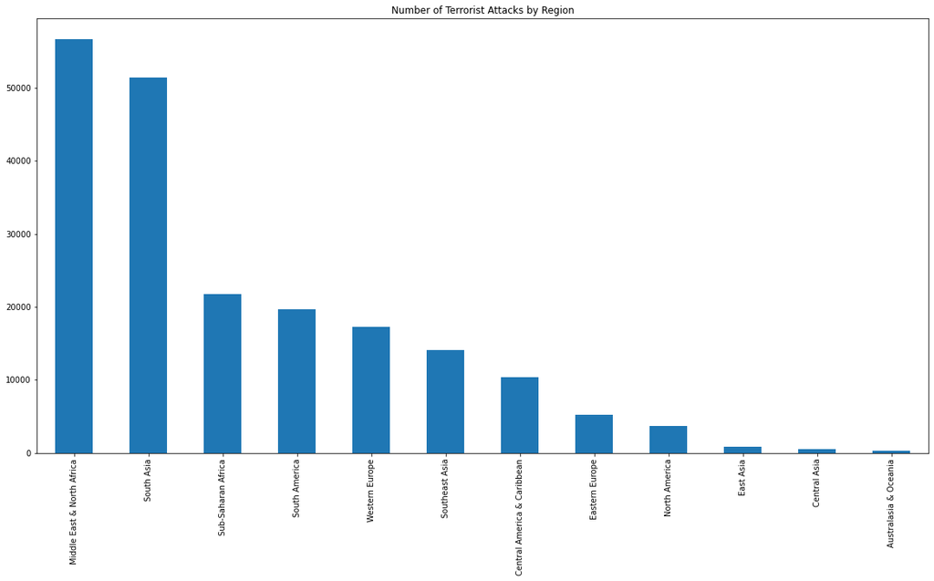

```python
fig, ax = plt.subplots(1,1)
region_cts = gtd_df['region_txt'].value_counts()
fig = region_cts.plot.bar(figsize=(20,10), title='Number of Terrorist Attacks by Region')
```

Create dataframes per region along with a list of region names for ease of use later.

```python
region_dfs = [gtd_df[gtd_df['region_txt'] == 'Western Europe'],
              gtd_df[gtd_df['region_txt'] == 'North America'],
              gtd_df[gtd_df['region_txt'] == 'Middle East & North Africa'],
              gtd_df[gtd_df['region_txt'] == 'South America'],
              gtd_df[gtd_df['region_txt'] == 'Southeast Asia'],
              gtd_df[gtd_df['region_txt'] == 'Sub-Saharan Africa'],
              gtd_df[gtd_df['region_txt'] == 'South Asia'],
              gtd_df[gtd_df['region_txt'] == 'Central America & Caribbean'],
              gtd_df[gtd_df['region_txt'] == 'Eastern Europe'],
              gtd_df[gtd_df['region_txt'] == 'East Asia'],
              gtd_df[gtd_df['region_txt'] == 'Australasia & Oceania'],
              gtd_df[gtd_df['region_txt'] == 'Central Asia']
             ]
region_names = ['Western Europe', 'North America', 'Middle East & North Africa', 'South America', 'Southeast Asia',
                'Sub-Saharan Africa', 'South Asia', 'Central America & Caribbean', 'Eastern Europe', 'East Asia',
                'Australasia & Oceania', 'Central Asia']
```

Interestingly enough, all terrorist attacks appear to have a staggering success rate. Central America & the Carribean have an incredibly low failure rate.

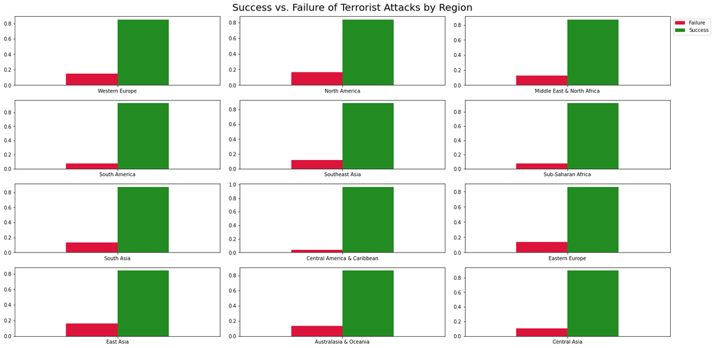

```python
fig, ax = plt.subplots(4, 3)
color_dict = {0.0:'crimson', 1.0:'forestgreen'}
labels = ['Success', 'Failure']
i = 0
fig.suptitle('Success vs. Failure of Terrorist Attacks by Region', fontsize=20)
for r in range(4):
    for c in range(3):
        ax[r,c] = (pd.crosstab(region_dfs[i]['region_txt'],
                               region_dfs[i]['success'],
                               normalize=True)).plot.bar(ax=ax[r,c], legend=False,figsize=(20,10), color=color_dict, rot=0)
        ax[r,c].set_xlabel('')
        i+=1
# Add a single legend and move it outside of the graph
ax[0, 2].legend(['Failure','Success'], bbox_to_anchor=(1.21,1))
fig.tight_layout()
```

Below are graphs displaying the frequency of terrorist attacks from 1970 - 2019 per region. However, something to consider is that the y-axis changes per graph, for if they all shared the same, it would lose information in regions with less terrorism attacks than others.

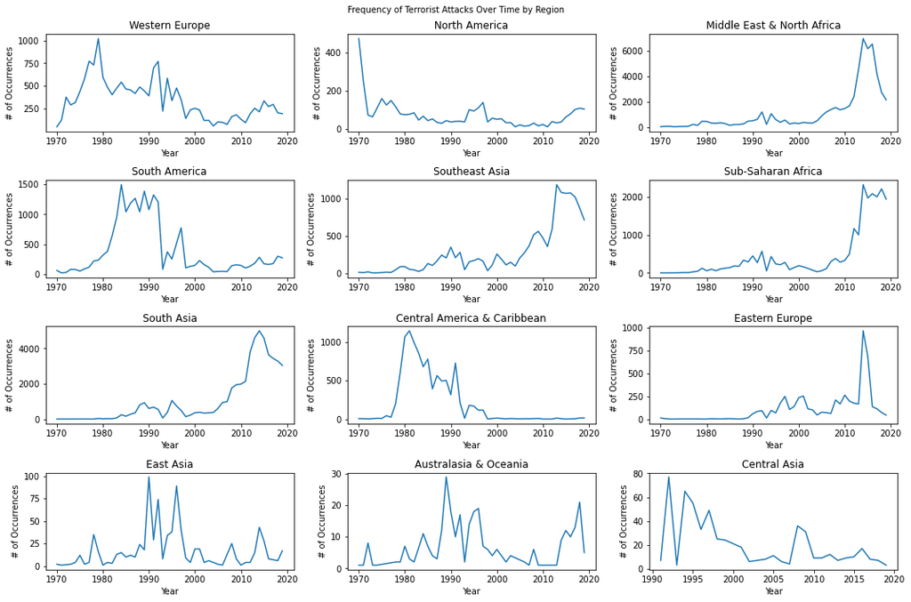

```python
fig, ax = plt.subplots(4, 3)
fig.suptitle('Frequency of Terrorist Attacks Over Time by Region', fontsize=10)
i = 0
for r in range(4):
    for c in range(3):
        region_dfs[i].groupby('iyear').crit1.count().plot(ax=ax[r,c], figsize=(15,10), title=region_names[i])
        i += 1
        ax[r,c].set_xlabel('Year')
        ax[r,c].set_ylabel('# of Occurrences')


fig.tight_layout()
```

There is a distinct spike in the frequency of terrorist attacks around 2013 in Middle East & North Africa, Southeast Asia, Sub-Saharan Africa, South Asia, and Eastern Europe. This may hold potential for analysis later, as it is not only a time period with large spikes in many regions, but also it suggests similar factors may be affecting the relevant regions

Next, we look at the proportions of the types of attacks on specific targets. It makes sense that abortion related acts of terror would involve a facility/infrastructure attack, as well as airports & aircraft having the highest relative proportion of hijacking.

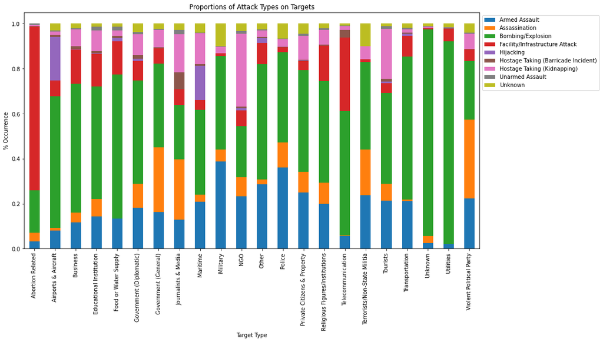

```python
fig, ax = plt.subplots(1,1)
targ_region_cts = pd.crosstab(gtd_df['targtype_txt'], gtd_df['attacktype_txt'])
targ_cts = targ_region_cts.sum(axis=1)
attk_cts = targ_region_cts.sum(axis=0)
region_given_targ = targ_region_cts.divide(targ_cts, axis=0)
fig = region_given_targ.plot.bar(ax=ax, stacked=True, figsize=(15,8), title='Proportions of Attack Types on Targets')
ax.set_xlabel('Target Type')
ax.set_ylabel('% Occurrence')
ax.legend(bbox_to_anchor=(1, 1))
```

To analyze a correlation between categorical variables, we must create dummy variables from them. Proceed to strip the correlation matrix to allow for easier plotting. In addition, strip the prefixes added by turning the values into dummy variables.

```python
tmp_df = gtd_df[['region_txt', 'targtype_txt']].copy()
terr_dummy = pd.get_dummies(tmp_df)
terr_dummy.drop(columns=['targtype_txt_Unknown'])
terr_corr = terr_dummy.corr()
terr_corr.drop(terr_corr.iloc[:, 12:], inplace = True, axis = 1)
terr_corr.drop(terr_corr.iloc[:, :12], inplace = True, axis = 0)

terr_corr.columns = terr_corr.columns.str.lstrip('region_txt_')
terr_corr = terr_corr.reset_index()
terr_corr['index'] = terr_corr['index'].str.lstrip('targtype_txt_')
```

The most difficult part of this was honestly figuring out how to color each bar and get a corresponding, single legend. In doing so, I was able to eliminate the x-labels which crowded up the majority of the graph space.

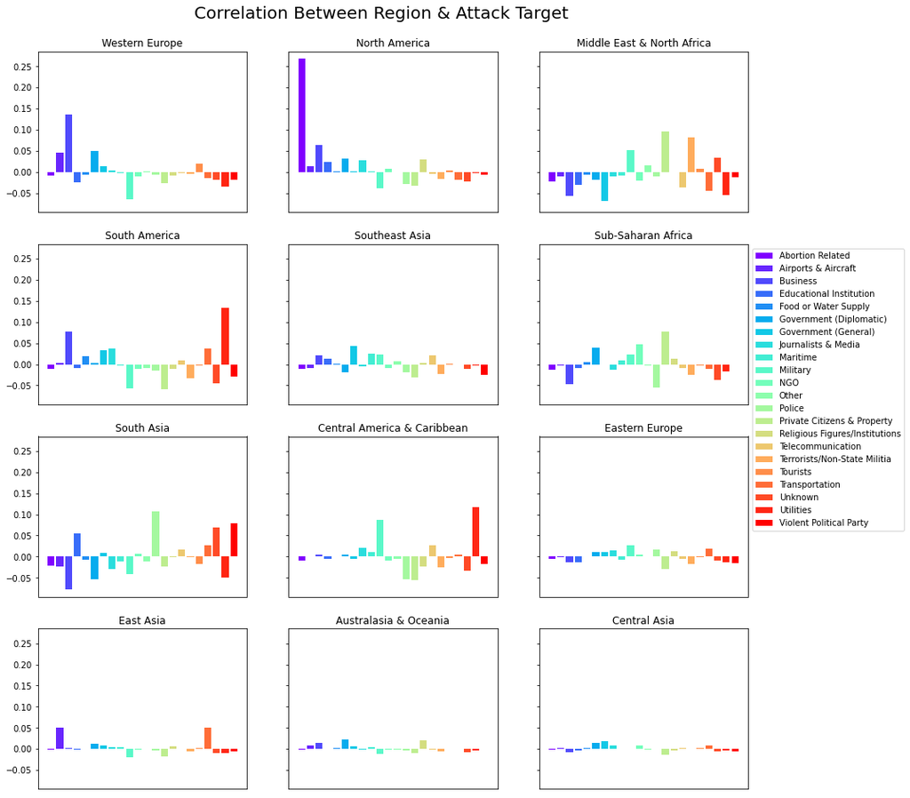

```python
fig, axs = plt.subplots(4, 3, figsize=(20,10), sharey=True)
fig.suptitle('Correlation Between Region & Attack Target', fontsize=20)
i = 0
color = cm.rainbow(np.linspace(0, 1, 22))
for t, ax in enumerate(axs.ravel()):
    x = terr_corr['index']
    height = terr_corr[region_names[i]]
    ax.bar(x, height, color=color)
    ax.set_title(region_names[i])
    ax.get_xaxis().set_visible(False)
    i+=1

custom_leg = []
for i, n in enumerate(terr_corr['index']):
    custom_leg.append(Patch(facecolor=color[i], label=n))
fig.set_figheight(15)
fig.set_figwidth(15)

handles = terr_corr['index']

# Add a single legend and move it outside of the graph
axs[1,2].legend(custom_leg, handles, bbox_to_anchor=(1,1))
fig.subplots_adjust(top=0.93)
```

Now, we have the correlation chart above, illustrating the disproportional abortion related attacks in North America as well as other information such as utilities being frequent targets in South America, Central America, and the Carribbean.

Let's take a closer look at the time period outlined in the graphs showing terrorist attacks over time; specifically, 5 regions between 2012 and 2019.

We create a mask that will filter out the relevant regions from the GTD. Then, we apply the mask and get the occurrences of terrorist attacks per country.

```python
mask = (gtd_df['region_txt'] == 'Middle East & North Africa') | (gtd_df['region_txt'] == 'Southeast Asia') | \
       (gtd_df['region_txt'] == 'South Asia') | (gtd_df['region_txt'] == 'Sub-Saharan Africa') | \
       (gtd_df['region_txt'] == 'Eastern Europe')

terr_cts = gtd_df[mask]['country_code'].value_counts()
terr_cts = gtd_df[gtd_df['iyear'] >= 2012]['country_code'].value_counts().sort_values(ascending=False)

terr_cts.head()
```

```
IRQ    18921
AFG    13275
PAK     9686
IND     6556
YEM     5094
Name: country_code, dtype: int64
```

We extract the relevant time period from GDELT. Then, we filter out the countries that had terrorist attacks within the aforementioned time frame from those regions. We must also filter out the actor type, for Actor1's perform an action ON Actor2.

e.g. when sanctions are imposed, Actor1 is the country imposing them, and Actor2 is the country being sanctioned

```python
gdelt_filt = gdelt_df[(gdelt_df['SQLDATE'].astype(int)>=20120101) & (
                           gdelt_df['SQLDATE'].astype(int)<20200101)]

terr1 = gdelt_filt[gdelt_filt['Actor1CountryCode'].isin(terr_cts.index)]
terr2 = gdelt_filt[gdelt_filt['Actor2CountryCode'].isin(terr_cts.index)]

terr1 = terr1[(terr1['Actor1Region'] == 'Southeast Asia') | (terr1['Actor1Region'] == 'Middle East & North Africa') |
              (terr1['Actor1Region'] == 'Sub-Saharan Africa') | (terr1['Actor1Region'] == 'South Asia')]

terr2 = terr2[(terr2['Actor2Region'] == 'Southeast Asia') | (terr2['Actor2Region'] == 'Middle East & North Africa') |
              (terr2['Actor2Region'] == 'Sub-Saharan Africa') | (terr2['Actor2Region'] == 'South Asia')]
```

Next, we take the GDELT event codes and extract only the codes corresponding to Actor1 or Actor2. Then, we turn each event into a dummy variable, allowing us to get how many events of each type occur per country.

```python
code1 = [104, 105, 153, 154, 166, 175, 164, 175]
code2 = [74, 81, 172, 163, 164, 165]
terr1 = terr1[['Actor1CountryCode','EventBaseCode']]

dum1 = pd.get_dummies(terr1['EventBaseCode'])
dum1 = dum1[code1]
dum1['country_code'] = terr1['Actor1CountryCode']
dum2 = pd.get_dummies(terr2['EventBaseCode'])
dum2 = dum2[code2]
dum2['country_code'] = terr2['Actor2CountryCode']
ev1 = dum1.groupby('country_code').sum()
ev2 = dum2.groupby('country_code').sum()

dum1 = dum1.reset_index(drop=True)
dum2 = dum2.reset_index(drop=True)

dummies = pd.concat([ev1, ev2], axis=1)
dummies['Terrorist attacks'] = terr_cts
dummies = dummies.rename(columns={166:'Expel peacekeepers', 175:'Use repression',
                                81:'Sanctions eased', 74:'Given military/peacekeepers',
                                104:'Demand political reform', 105:'Demand easing sanctions',
                                172: 'Sanctions imposed', 153:'Mobilize/increase police',
                                154: 'Mobilize/increase military', 163:'Impose embargo or boycott',
                                164: 'Negotiations halted', 165: 'Mediation halted'})
dummies.head()
```

| country_code | Demand political reform | Demand easing sanctions | Mobilize/increase police | Mobilize/increase military | Expel peacekeepers | Use repression | Negotiations halted | Use repression | Given military/peacekeepers | Sanctions eased | Sanctions imposed | Impose embargo or boycott | Negotiations halted | Mediation halted | Terrorist attacks |
| --- | --- | --- | --- | --- | --- | --- | --- | --- | --- | --- | --- | --- | --- | --- | --- |
| AFG | 531.0 | 0.0 | 620.0 | 8795.0 | 0.0 | 365.0 | 3032.0 | 365.0 | 611.0 | 757.0 | 8096.0 | 517.0 | 2341.0 | 12.0 | 13275 |
| AGO | 47.0 | 0.0 | 71.0 | 125.0 | 0.0 | 73.0 | 65.0 | 73.0 | 12.0 | 240.0 | 445.0 | 50.0 | 38.0 | 0.0 | 9 |
| ARE | 198.0 | 0.0 | 101.0 | 1169.0 | 0.0 | 192.0 | 328.0 | 192.0 | 27.0 | 656.0 | 4040.0 | 764.0 | 300.0 | 0.0 | 3 |
| BDI | 39.0 | 0.0 | 86.0 | 375.0 | 2.0 | 211.0 | 129.0 | 211.0 | 252.0 | 34.0 | 389.0 | 359.0 | 61.0 | 0.0 | 233 |
| BEN | 28.0 | 0.0 | 94.0 | 285.0 | 0.0 | 10.0 | 12.0 | 10.0 | 35.0 | 35.0 | 508.0 | 28.0 | 29.0 | 0.0 | 1 |

Let's look at the correlation between the frequency of these events against the frequency of terrorist attacks

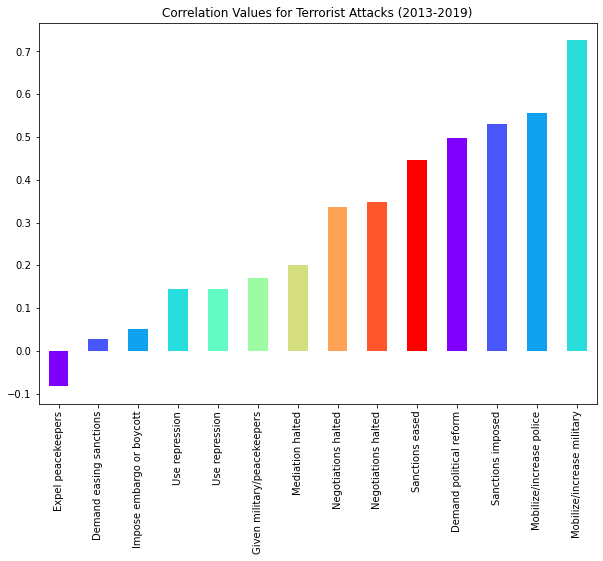

```python
corr_df = dummies.corr()
color = cm.rainbow(np.linspace(0, 1, 10))
corr_df['Terrorist attacks'].drop('Terrorist attacks').sort_values().plot.bar(title='Correlation Values for Terrorist Attacks (2013-2019)',
                                                                              figsize=(10,7), color=color)
```

## Hypothesis & Analysis

Let's take a look at multiple linear regressions between the most highly correlated events and terrorist attacks

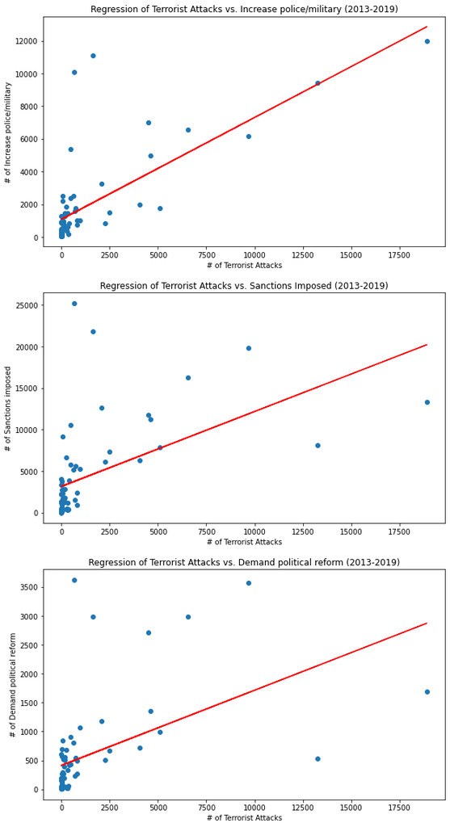

```python
fig, ax = plt.subplots((3), figsize=(10, 20))

# Combine the mobilization/increase of police and military
dummies['Increase police/military'] = dummies['Mobilize/increase police'] + dummies['Mobilize/increase military']

# Increase police/military
ax[0].scatter(dummies['Terrorist attacks'], dummies['Increase police/military'])

slope, intercept, r_value, p_value, std_err = stats.linregress(dummies['Terrorist attacks'], dummies['Increase police/military'])
reg_y = slope * dummies['Terrorist attacks'] + intercept
ax[0].plot(dummies['Terrorist attacks'], reg_y, color='r')
ax[0].set_ylabel('# of Increase police/military')
ax[0].set_xlabel('# of Terrorist Attacks')
ax[0].set_title('Regression of Terrorist Attacks vs. Increase police/military (2013-2019)')

# Sanctions imposed
ax[1].scatter(dummies['Terrorist attacks'], dummies['Sanctions imposed'])

slope, intercept, r_value, p_value, std_err = stats.linregress(dummies['Terrorist attacks'], dummies['Sanctions imposed'])
reg_y = slope * dummies['Terrorist attacks'] + intercept
ax[1].plot(dummies['Terrorist attacks'], reg_y, color='r')
ax[1].set_ylabel('# of Sanctions imposed')
ax[1].set_xlabel('# of Terrorist Attacks')
ax[1].set_title('Regression of Terrorist Attacks vs. Sanctions Imposed (2013-2019)')

# Demand political reform
ax[2].scatter(dummies['Terrorist attacks'], dummies['Demand political reform'])

slope, intercept, r_value, p_value, std_err = stats.linregress(dummies['Terrorist attacks'], dummies['Demand political reform'])
reg_y = slope * dummies['Terrorist attacks'] + intercept
ax[2].plot(dummies['Terrorist attacks'], reg_y, color='r')
ax[2].set_ylabel('# of Demand political reform')
ax[2].set_xlabel('# of Terrorist Attacks')
ax[2].set_title('Regression of Terrorist Attacks vs. Demand political reform (2013-2019)')
```

While there is a positive relationship indicated by the regression line, we already anticipated this via the correlations from earlier. Unfortunately, the large grouping of countries with low events and attacks impacts our model by heavily skewing the data.

In an attempt to see if two variables were more connected when linked to terrorist attack frequency than anticipated, we create a simple scatter plot comparing the increasing of police or military power with another event. Then, we have a color scale indicating the number of terrorist attacks.

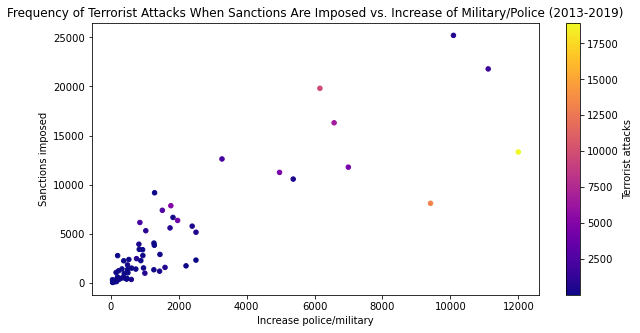

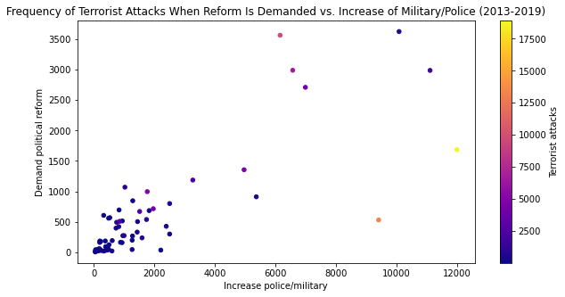

```python
# dummies = dummies.rename(columns={172:'Demand political reform'})
dummies['Increase police/military'] = dummies['Mobilize/increase police'] + dummies['Mobilize/increase military']
dummies.plot.scatter(x='Increase police/military', y='Sanctions imposed', c='Terrorist attacks', cmap='plasma', sharex=False,
                    figsize=(10,5), title='Frequency of Terrorist Attacks When Sanctions Are Imposed vs. Increase of Military/Police (2013-2019)')

# dummies = dummies.rename(columns={172:'Sanctions imposed'})
dummies['Increase police/military'] = dummies['Mobilize/increase police'] + dummies['Mobilize/increase military']
dummies.plot.scatter(x='Increase police/military', y='Demand political reform', c='Terrorist attacks', cmap='plasma', sharex=False,
                    figsize=(10,5), title='Frequency of Terrorist Attacks When Reform Is Demanded vs. Increase of Military/Police (2013-2019)')
```

As one could have predicted, we see simlar results to the previous regressions.

Regardless, this is about learning, so we will continue, and while the data may not work with the models, perhaps whoever is reading this can use them with a different data set.

Below, we implement a K-Nearest Neighbors algorithm with sanctions and increasing military/police as the features to produce a heatmap predicting the number of terrorist attacks

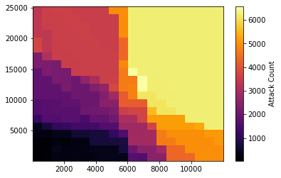

```python
from sklearn.feature_extraction import DictVectorizer
from sklearn.neighbors import KNeighborsRegressor
from sklearn.preprocessing import StandardScaler


fig, ax = plt.subplots()

num_sanc = dummies['Sanctions imposed']
num_mil = dummies['Increase police/military']
num_attk = dummies['Terrorist attacks']


features=['Increase police/military', 'Sanctions imposed']

def terr_k(fvals, k=30):
    x_dict = {k: v for k, v in zip(features, fvals)}

    x_train_dict = dummies[features].to_dict('records')
    y_train = dummies['Terrorist attacks']
    vec = DictVectorizer(sparse=False)
    vec.fit(x_train_dict)
    x_train = vec.transform(x_train_dict)
    x_new = vec.transform([x_dict])
    scaler = StandardScaler()
    scaler.fit(x_train)
    x_train_sc = scaler.transform(x_train)
    x_new_sc = scaler.transform(x_new)

    k_regressor = KNeighborsRegressor(n_neighbors=k)
    k_regressor.fit(x_train_sc, y_train)
    return k_regressor.predict(x_new_sc)

samples = 20

n_neighbors = 10

mil_min = num_mil.min()
mil_max = num_mil.max()
sanc_min = num_sanc.min()
sanc_max = num_sanc.max()

x_space = np.linspace(mil_min, mil_max, samples)
y_space = np.linspace(sanc_min, sanc_max, samples)

mesh = np.meshgrid(x_space, y_space)

knn_mesh = np.vectorize(lambda *fvals: terr_k(fvals, n_neighbors))(*mesh)

heat = ax.imshow(knn_mesh, cmap='inferno', origin='lower', aspect='auto',
               extent=[mil_min, mil_max, sanc_min, sanc_max])
plt.colorbar(heat, label='Attack Count')
```

We now look at various linear models that may help in predicting terrorist attacks based on our selected events. We will run them and compare the root mean squared error (RMSE) at the end.

```python
import sklearn
from sklearn import linear_model

dummies = dummies.dropna()

features = ['Increase police/military', 'Sanctions imposed', 'Demand political reform']

y_vals = dummies['Terrorist attacks'].values
x_vals = dummies[features]

#Splitting the data into training and testing data
X_train, X_test, y_train, y_test = sklearn.model_selection.train_test_split(x_vals, y_vals, test_size=0.2, random_state=0)

linear_model = sklearn.linear_model.LinearRegression()
lasso = sklearn.linear_model.Lasso()
lasso01 = sklearn.linear_model.Lasso(alpha = .01)
lasso0001 = sklearn.linear_model.Lasso(alpha = .0001)
ridge = sklearn.linear_model.Ridge()
ridge01 = sklearn.linear_model.Ridge(alpha = .01)
ridge100 = sklearn.linear_model.Ridge(alpha = 100)
```

```python
def get_rmse_5_fold(model):
    scores = sklearn.model_selection.cross_val_score(model, x_vals, y_vals, cv = 5, scoring="neg_mean_squared_error")
    mse = np.mean(-scores)
    rmse = np.sqrt(mse)
    return rmse

linear_model_rmse = get_rmse_5_fold(linear_model)
lasso_rmse = get_rmse_5_fold(lasso)
lasso01_rmse = get_rmse_5_fold(lasso01)
lasso0001_rmse = get_rmse_5_fold(lasso0001)
ridge_rmse = get_rmse_5_fold(ridge)
ridge01_rmse = get_rmse_5_fold(ridge01)
ridge100_rmse = get_rmse_5_fold(ridge100)
```

```python
#Displaying the rmse cross_val_scores of each model
print('Linear Model RMSE: ', linear_model_rmse)
print('Lasso RMSE: ', lasso_rmse)
print('Lasso with alpha = .01 RMSE: ', lasso01_rmse)
print('Lasso with alpha = .0001 RMSE: ', lasso0001_rmse)
print('Ridge RMSE: ', ridge_rmse)
print('Ridge with alpha = .01 RMSE: ', ridge01_rmse)
print('Ridge with alpha = 100 RMSE: ', ridge100_rmse)
```

```
Linear Model RMSE:  2707.121283895982
Lasso RMSE:  2707.1199000870215
Lasso with alpha = .01 RMSE:  2707.1212701023383
Lasso with alpha = .0001 RMSE:  2707.1212837571697
Ridge RMSE:  2707.1212422427025
Ridge with alpha = .01 RMSE:  2707.121283479447
Ridge with alpha = 100 RMSE:  2707.117118735806
```

Unfortunately, the RMSE is ridiculously high, rendering our models useless in any type of practical form.

```python
#Displaying the rmse cross_val_scores of each model
print('Linear Model RMSE: ', linear_model_rmse)
print('Lasso RMSE: ', lasso_rmse)
print('Lasso with alpha = .01 RMSE: ', lasso01_rmse)
print('Lasso with alpha = .0001 RMSE: ', lasso0001_rmse)
print('Ridge RMSE: ', ridge_rmse)
print('Ridge with alpha = .01 RMSE: ', ridge01_rmse)
print('Ridge with alpha = 100 RMSE: ', ridge100_rmse)
```

```
Linear Model RMSE:  2707.121283895982
Lasso RMSE:  2707.1199000870215
Lasso with alpha = .01 RMSE:  2707.1212701023383
Lasso with alpha = .0001 RMSE:  2707.1212837571697
Ridge RMSE:  2707.1212422427025
Ridge with alpha = .01 RMSE:  2707.121283479447
Ridge with alpha = 100 RMSE:  2707.117118735806
```

Despite having so many events, to be useful, the GDELT must be narrowed down so much so to answer incredibly broad questions such as "Can we identify factors that cause terrorism." As a result, there ends up not being enough data to answer said question, and the same issues can be found within analysis of the GTD. Despite an inconclusive conclusion, we can at least say we learned a lot while creating this notebook.